# Exploratory analysis: Substantive limits

This exploratory analysis focuses on the Substantive limits dimension and includes various data summaries in table and graphical forms.

# List of items

The Substantive Limits scale has been constructed on the basis of these items:

| Item | Question |
| --- | --- |
| 46 | Are there any prohibited issues? |
| 47 | Are referendums on constitutional amendments prohibited? |
| 48 | Are referendums related to international law obligations prohibited? |
| 49 | Are referendums related to fundamental rights and freedoms prohibited? |
| 50 | Are referendums on state structure or form of government prohibited? |
| 51 | Are referendums on state symbols prohibited? |
| 52 | Are referendums on the official language prohibited? |
| 53 | Are referendums on territorial issues or territorial integrity prohibited? |
| 54 | Are referendums on state finances (budget, taxes, or other financial obligations) prohibited? |
| 55 | Are referendums on issues related to national security (military, police, secret services) prohibited? |
| 56 | Are referendums on emergency powers (declaration of war, state of emergency etc) or urgent matters prohibited? |
| 57 | Are referendums on pardon and amnesty prohibited? |
| 58 | Are referendums on naturalisation issues prohibited? |
| 59 | Are referendums on minorities or minority rights prohibited? |
| 60 | Are referendums on the rules of elections and referendums prohibited? |
| 61 | Are referendums on the election or appointment of state officials or civil service laws prohibited? |
| 62 | Are referendums on legislative competences prohibited? |
| 63 | Are referendums on executive competences prohibited? |
| 64 | Are referendums on issues related to the judiciary (competences, independence etc) prohibited? |
| 65 | Are referendums on issues related to local governance prohibited? |
| 66 | Are there any other prohibited issues? |

**Note 1:** for the Law-initiated, Item 47 was not available.

**Note 2:** Item 46 is like a filter, if “No” then score is 0.

**Note 3:** Item 66 -on Other prohibitions- is not analysed.

# Data Summaries

### Overview

An overview per instrument of the number of cases where a substantive prohibition exists (i.e., a country provides for one of our 7 instruments and the answer to item 46 = “Yes”).

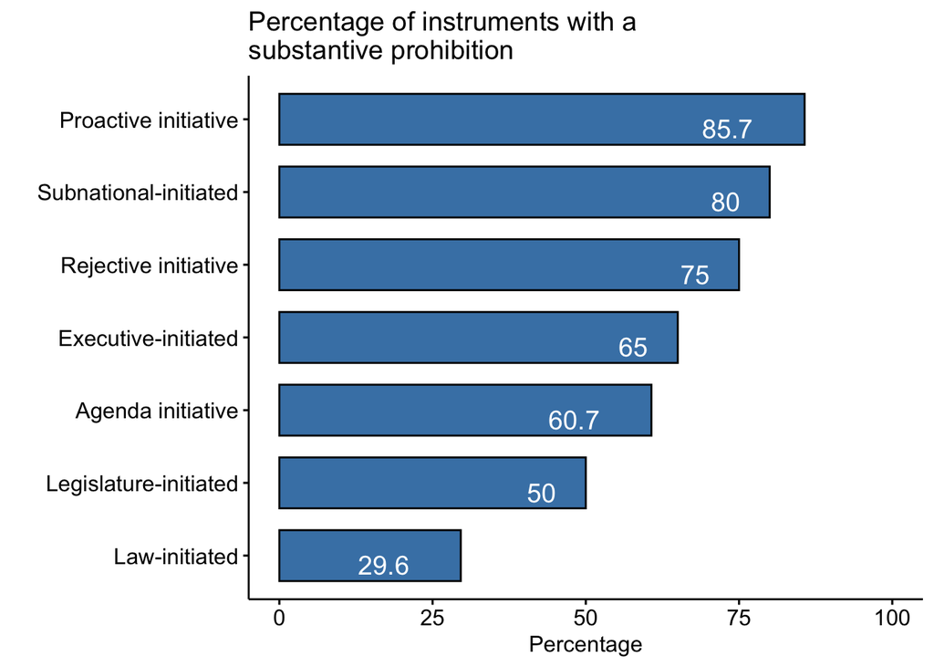

### Distribution of prohibitions

In all cases below, we have removed Item 46 (on general prohibitions) and Item 66 (on Other prohibitions). Furthermore we have excluded all cases where the answer to Item 46 is “No”. This means that the analysis below is ONLY for cases that have substantive prohibition(s). This is important and will enable us to see how the prohibitions are clustered among countries that have them.

The graph below looks at all the items (47:65) and counts the number of cases with prohibitions. It does so without distinguishing among the different Instruments. The Blue area represents all the “No” while yellow blocks are the “Yes” values. We use short labels instead of item IDs to make comparison easier.

#### Number of Yes/No per item (all Instruments combined)

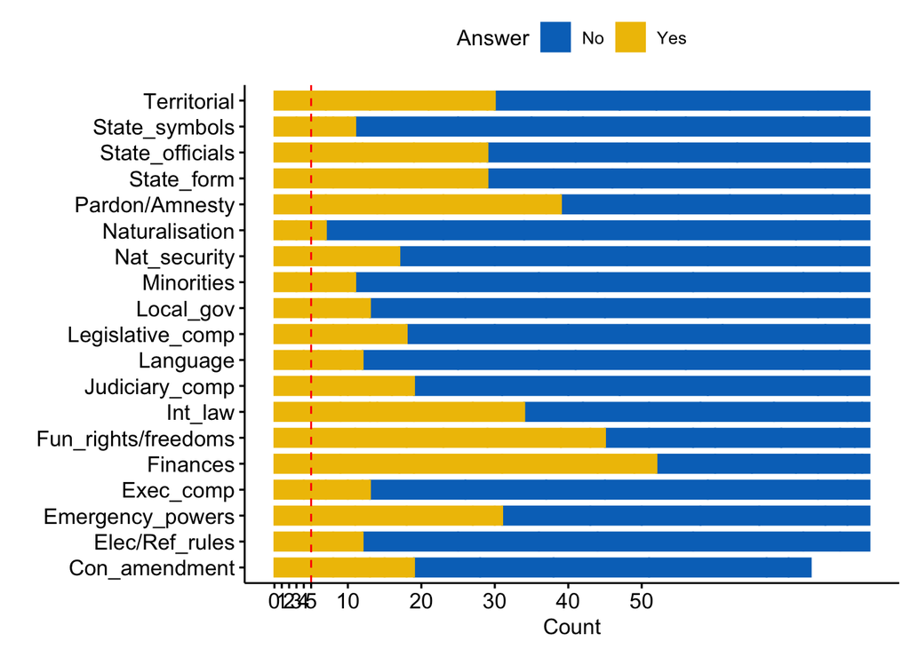

#### Tabular data (aggregated per item)

The same information can also be seen in easy way in an ordered table. Here we can see at the top of the table the highest “Yes” counts (in absolute numbers as well as a percentage). The very low “Yes” counts and “Yes” percentages are at the bottom.

| Item | Question | Yes_count | Percent_Yes |
| --- | --- | --- | --- |
| 54 | Are referendums on state finances (budget, taxes, or other financial obligations) prohibited? | 52 | 64 |
| 49 | Are referendums related to fundamental rights and freedoms prohibited? | 45 | 56 |
| 57 | Are referendums on pardon and amnesty prohibited? | 39 | 48 |
| 48 | Are referendums related to international law obligations prohibited? | 34 | 42 |
| 56 | Are referendums on emergency powers (declaration of war, state of emergency etc) or urgent matters prohibited? | 31 | 38 |
| 53 | Are referendums on territorial issues or territorial integrity prohibited? | 30 | 37 |
| 50 | Are referendums on state structure or form of government prohibited? | 29 | 36 |
| 61 | Are referendums on the election or appointment of state officials or civil service laws prohibited? | 29 | 36 |
| 47 | Are referendums on constitutional amendments prohibited? | 19 | 26 |
| 64 | Are referendums on issues related to the judiciary (competences, independence etc) prohibited? | 19 | 23 |
| 62 | Are referendums on legislative competences prohibited? | 18 | 22 |
| 55 | Are referendums on issues related to national security (military, police, secret services) prohibited? | 17 | 21 |
| 63 | Are referendums on executive competences prohibited? | 13 | 16 |
| 65 | Are referendums on issues related to local governance prohibited? | 13 | 16 |
| 52 | Are referendums on the official language prohibited? | 12 | 15 |
| 60 | Are referendums on the rules of elections and referendums prohibited? | 12 | 15 |
| 51 | Are referendums on state symbols prohibited? | 11 | 14 |
| 59 | Are referendums on minorities or minority rights prohibited? | 11 | 14 |
| 58 | Are referendums on naturalisation issues prohibited? | 7 | 9 |

The graph and table above are useful for seeing which type of Items produces high “Yes” and high “No” counts. The take home point in the graph above is that some items have very few cases. This mostly applies to item 58 on Naturalisation.

### Distributions by Instrument

The next graph does the same thing but further disaggregates by Instrument. The dahsed red line is set at 5 cases.

#### Number of Yes/No per item grouped by Instrument

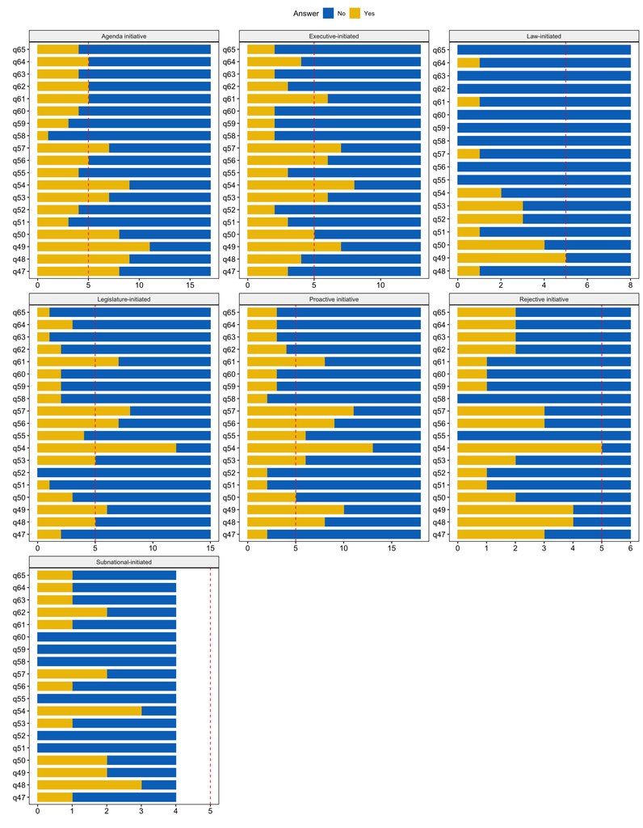

In this graph it’s possible to see that for instance Law-initiated has more totally blue areas -indicating all “No”, which is unsurprising given the nature of the Instrument.

# Country check

A country matrix allows us to check how Country affects substantive prohibitions. It is organised by the items on Y axis and the Countries on the X axis. The bubble represent the count (i.e., how many prohibitions a country has per item). This is related to the number of instruments a country has; thus a country with 5 instruments, will have a maximum number of 5 prohibitions.

Visualising these country effects allows us to see whether a particular country is driving the “Yes” count for a particular Item.

#### Matrix of ‘Yes’ value count for each item organised by country

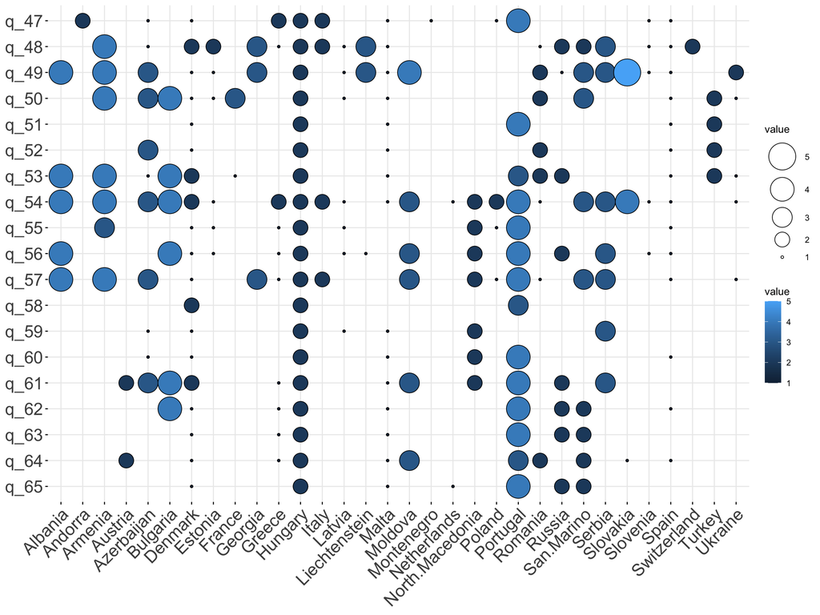

In the graph we can look at distributions by Item by focusing on horizontal axis (left-to-right) of a specific item. For instance we can see that Items 54 (Finances) and 49 (fundamental rights) have lots of bubbles, indicating lots of Yes answers (prohibitions). We can also see which items elicit few country bubbles. Item 58 (naturalisation) has only 3 bubbles in this regard.

### Summary

The situation has changed with the new country data, there are less potentially problematic items with very low counts than before. The rarest prohibition in this regard is Item 58 on Naturalisation.

# Annex

## Evaluation of scores

In the graph below we can place all cases on a putative Substantive Limits dimension. Because of the way the dimension has been measured -it has lots of items that are sparsely populated- there is little variation across the Instruments in terms of the average score. In other words, it is virtually impossible to get a high score because we have so many items/prohibitions. Some additional grouping of prohibitions might help to generate more meaningful comparisons.

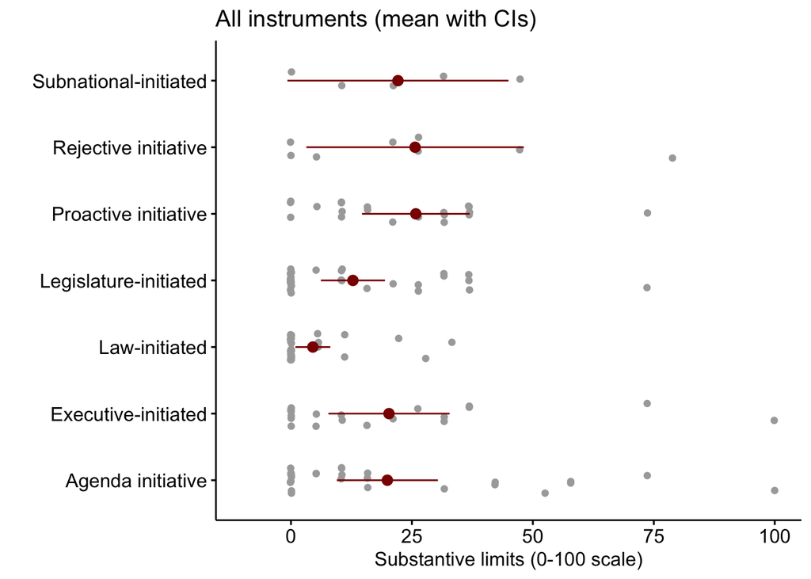